# Digital Signal Processing - Lecture 1

## Shift invariance

Both discrete systems represent the same system.

**Show plot code**

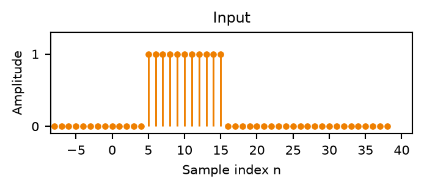

```python
samples = np.arange(-8, 39)
values = ((samples >= 5) & (samples <= 15)).astype(float)
fig, ax = plt.subplots(figsize=(3.5, 1.5), layout="constrained")
markers, stems, baseline = ax.stem(samples, values, basefmt=" ", label=None)
plt.setp(markers, color=HANZE_ORANGE, markersize=3)
plt.setp(stems, color=HANZE_ORANGE, linewidth=1.1)
baseline.set_visible(False)
ax.set(title="Input", xlabel="Sample index n", ylabel="Amplitude", ylim=(-0.1, 1.3), xlim=(-8.5, 41.5))
ax.set_xticks(np.arange(-5, 41, 5))
ax.set_yticks(np.arange(0, 2, 1))
plt.show()
plt.close(fig)
```

$x[n]$

Discrete  
system

$y[n]$

**Show plot code**

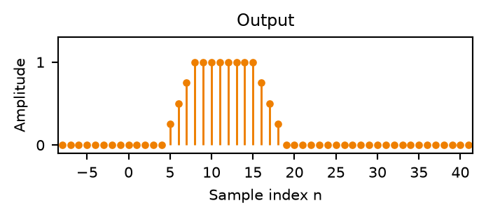

```python
input_indices = np.arange(-8, 39)
x = ((input_indices >= 5) & (input_indices <= 15)).astype(float)
impulse_response = np.array([0.25, 0.25, 0.25, 0.25])
values = np.convolve(x, impulse_response)
samples = np.arange(-8, 42)
fig, ax = plt.subplots(figsize=(3.5, 1.5), layout="constrained")
markers, stems, baseline = ax.stem(samples, values, basefmt=" ", label=None)
plt.setp(markers, color=HANZE_ORANGE, markersize=3)
plt.setp(stems, color=HANZE_ORANGE, linewidth=1.1)
baseline.set_visible(False)
ax.set(title="Output", xlabel="Sample index n", ylabel="Amplitude", ylim=(-0.1, 1.3), xlim=(-8.5, 41.5))
ax.set_xticks(np.arange(-5, 41, 5))
ax.set_yticks(np.arange(0, 2, 1))
plt.show()
plt.close(fig)
```

**Show plot code**

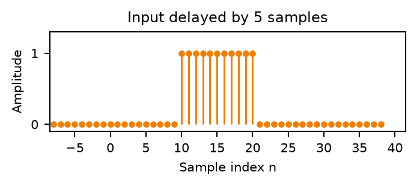

```python
samples = np.arange(-8, 39)
values = ((samples >= 10) & (samples <= 20)).astype(float)
fig, ax = plt.subplots(figsize=(3.5, 1.5), layout="constrained")
markers, stems, baseline = ax.stem(samples, values, basefmt=" ", label=None)
plt.setp(markers, color=HANZE_ORANGE, markersize=3)
plt.setp(stems, color=HANZE_ORANGE, linewidth=1.1)
baseline.set_visible(False)
ax.set(title="Input delayed by 5 samples", xlabel="Sample index n", ylabel="Amplitude", ylim=(-0.1, 1.3), xlim=(-8.5, 41.5))
ax.set_xticks(np.arange(-5, 41, 5))
ax.set_yticks(np.arange(0, 2, 1))
plt.show()
plt.close(fig)
```

$x[n-5]$

Discrete  
system

$y[n-5]$

**Show plot code**

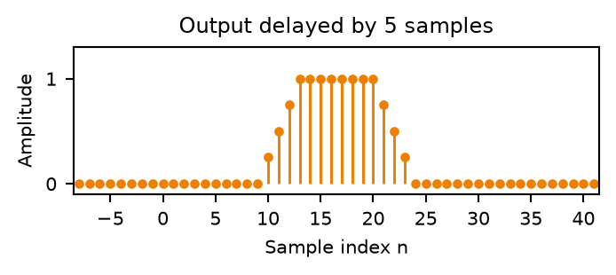

```python
input_indices = np.arange(-8, 39)
x = ((input_indices >= 10) & (input_indices <= 20)).astype(float)
impulse_response = np.array([0.25, 0.25, 0.25, 0.25])
values = np.convolve(x, impulse_response)
samples = np.arange(-8, 42)
fig, ax = plt.subplots(figsize=(3.5, 1.5), layout="constrained")
markers, stems, baseline = ax.stem(samples, values, basefmt=" ", label=None)
plt.setp(markers, color=HANZE_ORANGE, markersize=3)
plt.setp(stems, color=HANZE_ORANGE, linewidth=1.1)
baseline.set_visible(False)
ax.set(title="Output delayed by 5 samples", xlabel="Sample index n", ylabel="Amplitude", ylim=(-0.1, 1.3), xlim=(-8.5, 41.5))
ax.set_xticks(np.arange(-5, 41, 5))
ax.set_yticks(np.arange(0, 2, 1))
plt.show()
plt.close(fig)
```

Shift invariant. Delaying the input by 5 samples delays the output by the same 5 samples.

## Shift invariant?

Both discrete systems represent the same system.

Original input

**Show plot code**

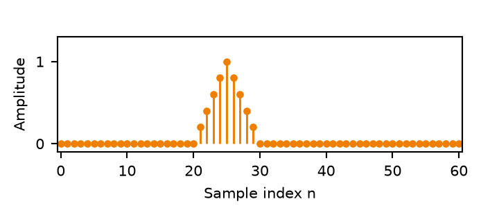

```python
samples = np.arange(77)
values = np.maximum(0, 1 - np.abs(samples - 25) / 5)
fig, ax = plt.subplots(figsize=(3.5, 1.5), layout="constrained")
markers, stems, baseline = ax.stem(samples, values, basefmt=" ", label=None)
plt.setp(markers, color=HANZE_ORANGE, markersize=3)
plt.setp(stems, color=HANZE_ORANGE, linewidth=1.1)
baseline.set_visible(False)
ax.set(title=" ", xlabel="Sample index n", ylabel="Amplitude", ylim=(-0.1, 1.3), xlim=(-0.5, 60.5))
ax.set_xticks(np.arange(0, 61, 10))
ax.set_yticks(np.arange(0, 2, 1))
plt.show()
plt.close(fig)
```

$x[n]$

Discrete  
system

$y[n]$

Original output

**Show plot code**

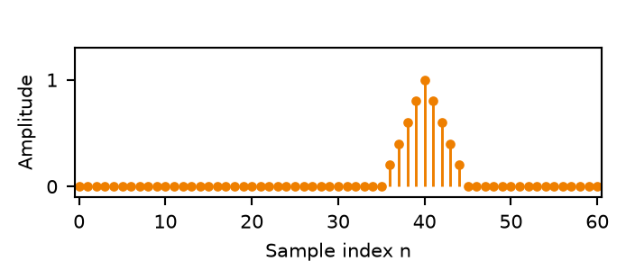

```python
samples = np.arange(77)
x = np.maximum(0, 1 - np.abs(samples - 25) / 5)
values = np.maximum(0, 1 - np.abs((65 - samples) - 25) / 5)
fig, ax = plt.subplots(figsize=(3.5, 1.5), layout="constrained")
markers, stems, baseline = ax.stem(samples, values, basefmt=" ", label=None)
plt.setp(markers, color=HANZE_ORANGE, markersize=3)
plt.setp(stems, color=HANZE_ORANGE, linewidth=1.1)
baseline.set_visible(False)
ax.set(title=" ", xlabel="Sample index n", ylabel="Amplitude", ylim=(-0.1, 1.3), xlim=(-0.5, 60.5))
ax.set_xticks(np.arange(0, 61, 10))
ax.set_yticks(np.arange(0, 2, 1))
plt.show()
plt.close(fig)
```

Input shifted left by 15 samples

**Show plot code**

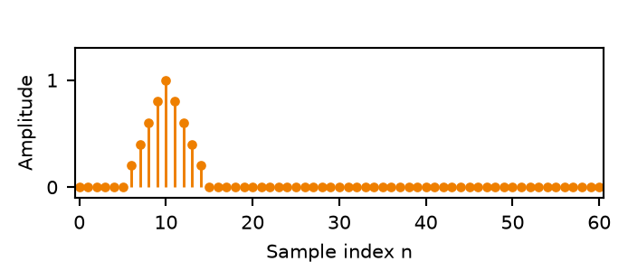

```python
samples = np.arange(77)
values = np.maximum(0, 1 - np.abs(samples - 10) / 5)
fig, ax = plt.subplots(figsize=(3.5, 1.5), layout="constrained")
markers, stems, baseline = ax.stem(samples, values, basefmt=" ", label=None)
plt.setp(markers, color=HANZE_ORANGE, markersize=3)
plt.setp(stems, color=HANZE_ORANGE, linewidth=1.1)
baseline.set_visible(False)
ax.set(title=" ", xlabel="Sample index n", ylabel="Amplitude", ylim=(-0.1, 1.3), xlim=(-0.5, 60.5))
ax.set_xticks(np.arange(0, 61, 10))
ax.set_yticks(np.arange(0, 2, 1))
plt.show()
plt.close(fig)
```

$x[n+15]$

Discrete  
system

$y[n-15]$

Output shifted right by 15 samples

**Show plot code**

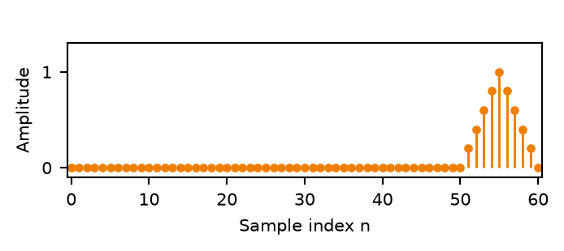

```python
samples = np.arange(77)
x = np.maximum(0, 1 - np.abs(samples - 10) / 5)
values = np.maximum(0, 1 - np.abs((65 - samples) - 10) / 5)
fig, ax = plt.subplots(figsize=(3.5, 1.5), layout="constrained")
markers, stems, baseline = ax.stem(samples, values, basefmt=" ", label=None)
plt.setp(markers, color=HANZE_ORANGE, markersize=3)
plt.setp(stems, color=HANZE_ORANGE, linewidth=1.1)
baseline.set_visible(False)
ax.set(title=" ", xlabel="Sample index n", ylabel="Amplitude", ylim=(-0.1, 1.3), xlim=(-0.5, 60.5))
ax.set_xticks(np.arange(0, 61, 10))
ax.set_yticks(np.arange(0, 2, 1))
plt.show()
plt.close(fig)
```

Not shift invariant. The input moves left, but the actual output moves right.  
In other words, when the input occurs earlier, the output occurs later.

## LTI systems in three rules

A system that creates an output $y[n]$ for a given input $x[n]$ is LTI if it satisfies the properties of linearity and shift invariance. In these slides, $\to$ indicates the input-output relationship of the system.

Homogeneity

Scale input and output equally.

$$a\,x[n]\to a\,y[n]$$

Additivity

Add inputs and their outputs.

Given $x_1[n]\to y_1[n]$ and $x_2[n]\to y_2[n]$

$$x_1[n]+x_2[n]\to y_1[n]+y_2[n]$$

Shift invariance

Shift input and output equally. Also referred to as time invariance.

$$x[n-n_0]\to y[n-n_0]$$

**Homogeneity + additivity = linearity**  
Linearity + shift invariance = LTI

## Questions?

# Unit impulse

Discrete-time unit impulse

## Discrete unit impulse

$$\delta[n]=\begin{cases}1,&n=0,\\0,&n\ne0.\end{cases}$$

**Show plot code**

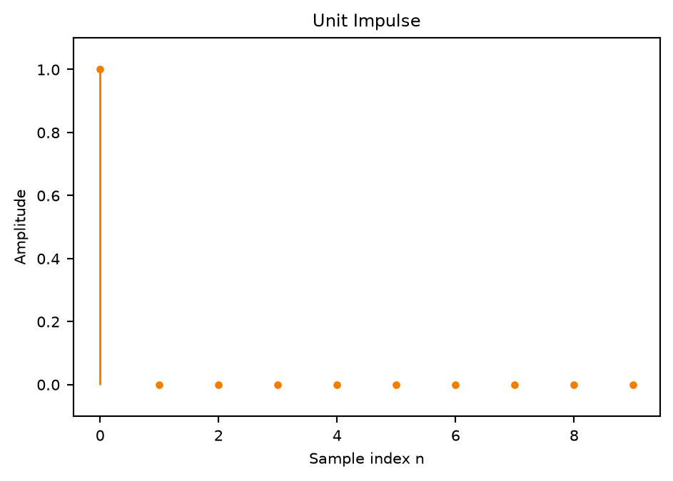

```python
samples = np.arange(0, 10)
values = np.zeros(10)
values[0] = 1
fig, ax = plt.subplots(figsize=(4.8, 3.4), layout="constrained")
markers, stems, baseline = ax.stem(samples, values, basefmt=" ", label=None)
plt.setp(markers, color=HANZE_ORANGE, markersize=3)
plt.setp(stems, color=HANZE_ORANGE, linewidth=1.1)
baseline.set_visible(False)
ax.set(title='Unit Impulse', xlabel='Sample index n', ylabel="Amplitude", ylim=(-0.1, 1.1))
plt.show()
plt.close(fig)
```

# Impulse response

## Impulse response

**Show plot code**

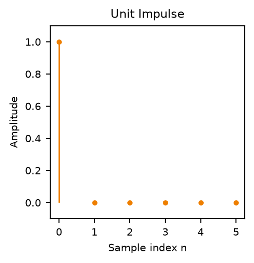

```python
samples = np.arange(0, 6)
values = np.zeros(6)
values[0] = 1
fig, ax = plt.subplots(figsize=(2.6, 2.7), layout="constrained")
markers, stems, baseline = ax.stem(samples, values, basefmt=" ", label=None)
plt.setp(markers, color=HANZE_ORANGE, markersize=3)
plt.setp(stems, color=HANZE_ORANGE, linewidth=1.1)
baseline.set_visible(False)
ax.set(title='Unit Impulse', xlabel='Sample index n', ylabel="Amplitude", ylim=(-0.1, 1.1))
plt.show()
plt.close(fig)
```

$\delta[n]$

$h[n]=$  
$[1, 0.5]$

$\color{black}{h[n]}$

**Show plot code**

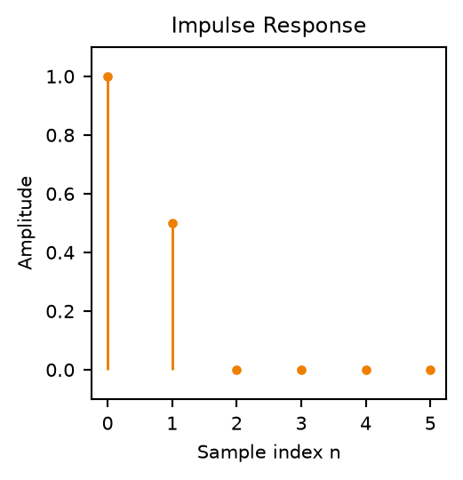

```python
samples = np.arange(0, 6)
impulse_response = np.array([1.0, 0.5])
values = np.pad(impulse_response, (0, 6 - len(impulse_response)))
fig, ax = plt.subplots(figsize=(2.6, 2.7), layout="constrained")
markers, stems, baseline = ax.stem(samples, values, basefmt=" ", label=None)
plt.setp(markers, color=HANZE_ORANGE, markersize=3)
plt.setp(stems, color=HANZE_ORANGE, linewidth=1.1)
baseline.set_visible(False)
ax.set(title='Impulse Response', xlabel='Sample index n', ylabel="Amplitude", ylim=(-0.1, 1.1))
plt.show()
plt.close(fig)
```

The output for a unit impulse is the system’s impulse response.

## Discrete-time impulse response

$$x[n] \quad \longrightarrow \quad h[n] \quad \longrightarrow \quad y[n]$$

## Discrete-time impulse response example

**Show plot code**

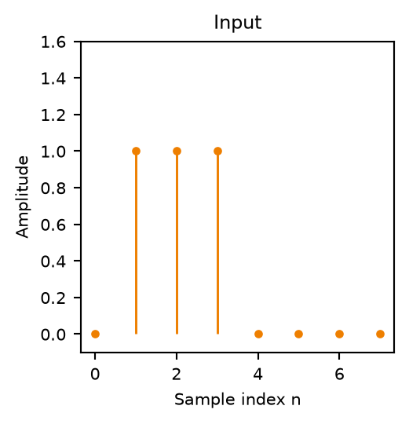

```python
samples = np.arange(0, 8)
values = np.array([0, 1, 1, 1, 0, 0, 0, 0])
fig, ax = plt.subplots(figsize=(2.6, 2.7), layout="constrained")
markers, stems, baseline = ax.stem(samples, values, basefmt=" ", label=None)
plt.setp(markers, color=HANZE_ORANGE, markersize=3)
plt.setp(stems, color=HANZE_ORANGE, linewidth=1.1)
baseline.set_visible(False)
ax.set(title='Input', xlabel='Sample index n', ylabel="Amplitude", ylim=(-0.1, 1.6))
plt.show()
plt.close(fig)
```

$→$

**Show plot code**

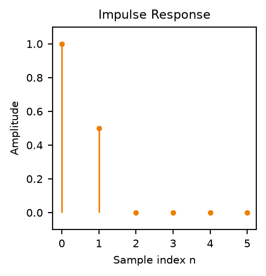

```python
samples = np.arange(0, 6)
impulse_response = np.array([1.0, 0.5])
values = np.pad(impulse_response, (0, 6 - len(impulse_response)))
fig, ax = plt.subplots(figsize=(2.6, 2.7), layout="constrained")
markers, stems, baseline = ax.stem(samples, values, basefmt=" ", label=None)
plt.setp(markers, color=HANZE_ORANGE, markersize=3)
plt.setp(stems, color=HANZE_ORANGE, linewidth=1.1)
baseline.set_visible(False)
ax.set(title='Impulse Response', xlabel='Sample index n', ylabel="Amplitude", ylim=(-0.1, 1.1))
plt.show()
plt.close(fig)
```

$→$

**Show plot code**

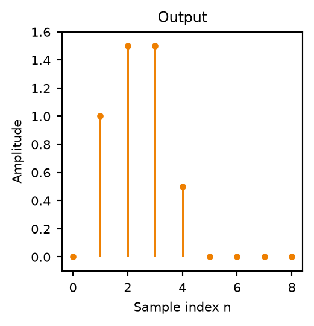

```python
samples = np.arange(0, 9)
x = np.array([0, 1, 1, 1, 0, 0, 0, 0])
impulse_response = np.array([1.0, 0.5])
y = np.convolve(x, impulse_response)
values = y
fig, ax = plt.subplots(figsize=(2.6, 2.7), layout="constrained")
markers, stems, baseline = ax.stem(samples, values, basefmt=" ", label=None)
plt.setp(markers, color=HANZE_ORANGE, markersize=3)
plt.setp(stems, color=HANZE_ORANGE, linewidth=1.1)
baseline.set_visible(False)
ax.set(title='Output', xlabel='Sample index n', ylabel="Amplitude", ylim=(-0.1, 1.6))
plt.show()
plt.close(fig)
```

$$x[n] \quad \longrightarrow \quad h[n] \quad \longrightarrow \quad y[n]$$

For an LTI system, add scaled and shifted copies of h[n] to find the output.

## What input happened here? 1

?

**Show plot code**

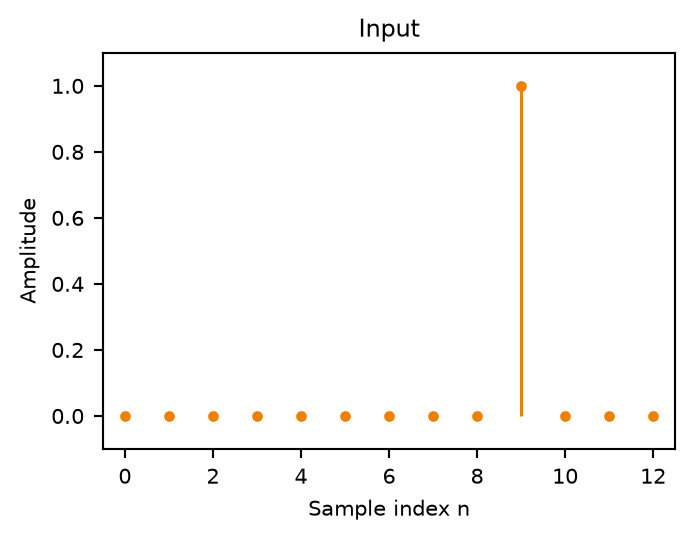

```python
samples = np.arange(0, 20)
x = np.zeros(20)
x[9] = 1
impulse_response = np.array([1.0, 0.5])
values = x
fig, ax = plt.subplots(figsize=(3.5, 2.7), layout="constrained")
markers, stems, baseline = ax.stem(samples, values, basefmt=" ", label=None)
plt.setp(markers, color=HANZE_ORANGE, markersize=3)
plt.setp(stems, color=HANZE_ORANGE, linewidth=1.1)
baseline.set_visible(False)
ax.set(title='Input', xlabel='Sample index n', ylabel="Amplitude", ylim=(-0.1, 1.1))
ax.set_xlim(-0.5, 12.5)
ax.set_xticks(np.arange(0, 13, 2))
plt.show()
plt.close(fig)
```

$x[n]$

$h[n]=$  
$[1, 0.5]$

$y[n]$

**Show plot code**

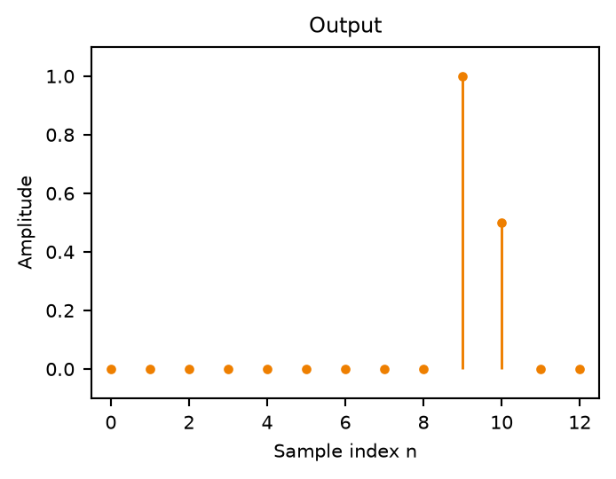

```python
samples = np.arange(0, 21)
x = np.zeros(20)
x[9] = 1
impulse_response = np.array([1.0, 0.5])
values = np.convolve(x, impulse_response)
fig, ax = plt.subplots(figsize=(3.5, 2.7), layout="constrained")
markers, stems, baseline = ax.stem(samples, values, basefmt=" ", label=None)
plt.setp(markers, color=HANZE_ORANGE, markersize=3)
plt.setp(stems, color=HANZE_ORANGE, linewidth=1.1)
baseline.set_visible(False)
ax.set(title='Output', xlabel='Sample index n', ylabel="Amplitude", ylim=(-0.1, 1.1))
ax.set_xlim(-0.5, 12.5)
ax.set_xticks(np.arange(0, 13, 2))
plt.show()
plt.close(fig)
```

$x[n]=\delta[n-9]$

The output is h[n] shifted 9 samples right, so the input is a unit impulse at n = 9.

## What input happened here? 2

?

**Show plot code**

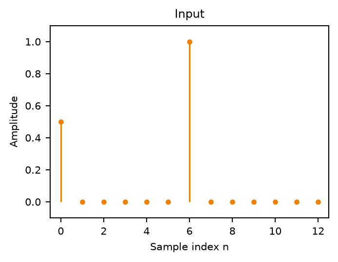

```python
samples = np.arange(0, 20)
x = np.zeros(20)
x[0] = 0.5
x[6] = 1
impulse_response = np.array([1.0, 0.5])
values = x
fig, ax = plt.subplots(figsize=(3.5, 2.7), layout="constrained")
markers, stems, baseline = ax.stem(samples, values, basefmt=" ", label=None)
plt.setp(markers, color=HANZE_ORANGE, markersize=3)
plt.setp(stems, color=HANZE_ORANGE, linewidth=1.1)
baseline.set_visible(False)
ax.set(title='Input', xlabel='Sample index n', ylabel="Amplitude", ylim=(-0.1, 1.1))
ax.set_xlim(-0.5, 12.5)
ax.set_xticks(np.arange(0, 13, 2))
plt.show()
plt.close(fig)
```

$x[n]$

$h[n]=$  
$[1, 0.5]$

$y[n]$

**Show plot code**

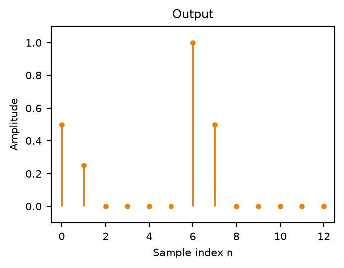

```python
samples = np.arange(0, 21)
x = np.zeros(20)
x[0] = 0.5
x[6] = 1
impulse_response = np.array([1.0, 0.5])
values = np.convolve(x, impulse_response)
fig, ax = plt.subplots(figsize=(3.5, 2.7), layout="constrained")
markers, stems, baseline = ax.stem(samples, values, basefmt=" ", label=None)
plt.setp(markers, color=HANZE_ORANGE, markersize=3)
plt.setp(stems, color=HANZE_ORANGE, linewidth=1.1)
baseline.set_visible(False)
ax.set(title='Output', xlabel='Sample index n', ylabel="Amplitude", ylim=(-0.1, 1.1))
ax.set_xlim(-0.5, 12.5)
ax.set_xticks(np.arange(0, 13, 2))
plt.show()
plt.close(fig)
```

$x[n]=0.5\delta[n]+\delta[n-6]$

The output combines half of h[n] at n = 0 and a full copy at n = 6, so the input contains impulses of 0.5 and 1 at those indices.

## What input happened here? 3

?

**Show plot code**

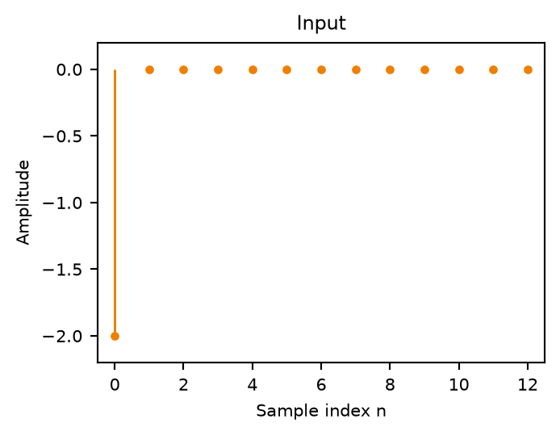

```python
samples = np.arange(0, 20)
x = np.zeros(20)
x[0] = -2
impulse_response = np.array([1.0, 0.5])
values = x
fig, ax = plt.subplots(figsize=(3.5, 2.7), layout="constrained")
markers, stems, baseline = ax.stem(samples, values, basefmt=" ", label=None)
plt.setp(markers, color=HANZE_ORANGE, markersize=3)
plt.setp(stems, color=HANZE_ORANGE, linewidth=1.1)
baseline.set_visible(False)
ax.set(title='Input', xlabel='Sample index n', ylabel="Amplitude", ylim=(-2.2, 0.2))
ax.set_xlim(-0.5, 12.5)
ax.set_xticks(np.arange(0, 13, 2))
plt.show()
plt.close(fig)
```

$x[n]$

$h[n]=$  
$[1, 0.5]$

$y[n]$

**Show plot code**

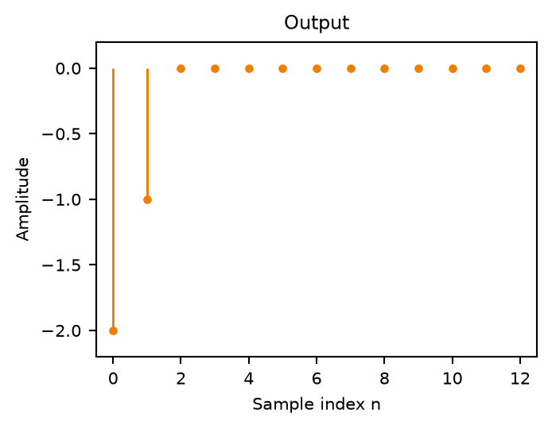

```python
samples = np.arange(0, 21)
x = np.zeros(20)
x[0] = -2
impulse_response = np.array([1.0, 0.5])
values = np.convolve(x, impulse_response)
fig, ax = plt.subplots(figsize=(3.5, 2.7), layout="constrained")
markers, stems, baseline = ax.stem(samples, values, basefmt=" ", label=None)
plt.setp(markers, color=HANZE_ORANGE, markersize=3)
plt.setp(stems, color=HANZE_ORANGE, linewidth=1.1)
baseline.set_visible(False)
ax.set(title='Output', xlabel='Sample index n', ylabel="Amplitude", ylim=(-2.2, 0.2))
ax.set_xlim(-0.5, 12.5)
ax.set_xticks(np.arange(0, 13, 2))
plt.show()
plt.close(fig)
```

$x[n]=-2\delta[n]$

The output is h[n] multiplied by −2 without a shift, so the input is an impulse of −2 at n = 0.

# Exercises

## Do not forget the exercises!

../exercises/DSP-Lecture-01-Exercises.ipynb